# Gurnard in static background

Richard Southwell

Wed Jan 03 21:49:49 2018

```r
library(mizer)
```

We want to investigate how well the mizer numerics can reproduce the analytic solution that we can obtain in the case of non-interacting species.

## Without density dependence

### Set parameters

```r
#f0 <- 0.6
#alpha <- 0.4
r_pp <- 10^18  # Choosing a high value because we want the plankton to stay
# at its power-law steady state
n <- 2/3
p <- n
q <- 0.7
lambda <- 2+q-n
#erepro <- 0.1
R <- 1e10  # The rate of reproduction

#beta <- 100
#sigma <- 1.3
#h <- 30
#ks <- 4
kappa <- 7e10

#w_min <- 1e-2
#w_inf <- 1e3
#w_mat <- 10^2.4  # About 251, a quarter of w_inf
#min_w_pp <- 1e-7  # Only have to make sure the smallest fish are perfectly fed
# Chose number of gridpoints so that w_mat and w_inf lie on gridpoints
#no_w <- log10(w_inf/w_min)*100+1

#######################################

# Gurnard Parameters
beta <- 283
sigma <- 1.8
k_vb <- 0.266
alpha <- 0.6
h <- 19.37727
gamma <- 2.948552e-11
#z0 <- 0.06863713
z0 <- 0
ks <- 3.875454
erepro <- 0.1
```

used (3.17) to get f0 from gamma. Note this should be corrected when chi>0

```r
f0 <- gamma/(gamma+h*exp(-((lambda-2)^2)*sigma*sigma/2)*(beta^(2-lambda))/(sqrt(2*pi)*kappa*sigma))

# # # # weight specifiers

no_w <- 2000
w_min <- 1e-3
w_inf <- 668
w_mat <- 39
min_w_pp <- exp(-5*sigma)*w_min/beta  # Only have to make sure the smallest fish are perfectly fed

## ## ## ## ## ##

species_params <- data.frame(
  species = "Single",
  w_min = w_min,
  w_inf = w_inf,
  w_mat = w_mat,
  h = h,
  ks = ks,
  beta = beta,
  sigma = sigma,
  z0 = 0,
  alpha = alpha,
  erepro = erepro,
  sel_func = "knife_edge", # not used but required
  knife_edge_size = 1000,
  gamma = gamma
)

params <- MizerParams(species_params, p=p, n=n, q=q, lambda = lambda, f0 = f0,
                      kappa = kappa, min_w = w_min, max_w = w_inf, no_w = no_w,
                      min_w_pp = min_w_pp, w_pp_cutoff = w_inf, r_pp = r_pp)

gamma <- params@species_params$gamma[1]
w <- params@w
```

### Exact solution

We set the background death to $\mu_0 w^{n-1}$ and choose
$$\mu_0 = (1-f_0) \sqrt{2\pi} \kappa \gamma \sigma
\beta^{n-1} \exp(\sigma^2 (n-1)^2 / 2)$$
which is the death rate that is produced by predation if the predators follow the same power law as the plankton. We could equally well have chosen any other constant for $\mu_0$.

```r
mu0 <- (1-f0) * sqrt(2*pi) * kappa * gamma * sigma *
  (beta^(n-1)) * exp(sigma^2 * (n-1)^2 / 2)
params@mu_b[1, ] <- mu0 * w^(n-1)
```

The rate at which energy is available for growth and reproduction is $\bar{h} w^n$, with $\bar{h} = \alpha h f_0 - k_s$.

```r
hbar <- alpha * h * f0 - ks
```

n_exact is calculated using the analytic expression for the solution,
$$N(w) = \frac{R}{\bar{h} w^n} (w_0/w)^{\mu_0/\bar{h}}
\times \begin{cases} 1 & w<w_{mat}\\
\left(1-(w/W_{inf})^{1-n}\right)^{\mu_0/\bar{h}/(1-n)-1}
\left(1-(w_{mat}/W_{inf})^{1-n}\right)^{-\mu_0/\bar{h}/(1-n)} & w>w_{mat}
\end{cases}$$

```r
pow <- mu0/hbar/(1-n)
n_mult <- (1 - (w/w_inf)^(1-n))^(pow-1) * (1 - (w_mat/w_inf)^(1-n))^(-pow)
n_mult[w < w_mat] <- 1
n_exact <- params@psi  # Just to get array with correct dimensions and names
n_exact[] <- R * (w_min/w)^(mu0/hbar) / (hbar * w^n) * n_mult
n_exact[length(n_exact)] <- n_exact[length(n_exact)-1]
```

### Mizer setup for non-interacting scenario

Make sure that the rate of reproduction is R

```r
params@srr <- function(rdi, species_params) {return(species_params$R)}
params@species_params$R <- R
```

```r
params@psi[1, ] <- (w/w_inf)^(1-n)
params@psi[1, w < w_mat] <- 0
params@psi[1, w > w_inf] <- 1
```

We switch off the self-interaction

```r
params@interaction[] <- 0
```

We start the simulation with the exact steady-state solution

```r
sim <- project(params, t_max=50, effort = 0, initial_n = n_exact)
```

### Comparison of solutions

If all is well, it should stay close to the steady-state solution.

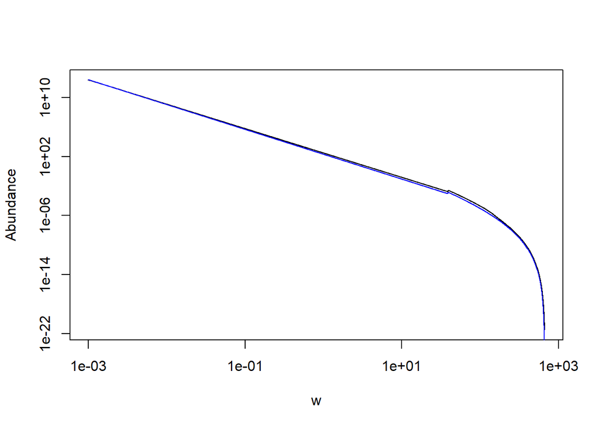

```r
plot(w, sim@n[dim(sim@n)[1],1,], log="xy", type="l", ylab="Abundance")
lines(w, n_exact[1,], col="blue")
```

we shall turn on prey-switching before letting R become dynamic we do this to keep things stable, but it remains an interesting question what is the stability when $\chi=0$, which we should indeed study

## With density dependence

Now we repeat the same calculation with the same parameters, except that we turn on density dependence

```r
chi <- 0.05
ddd <- (kappa * w_mat^(-lambda))^chi
params@chi <- chi
params@ddd <- ddd
params@mu_b[1, ] <- mu0 * w^(n-1) * ddd
```

Now there is no elementary analytic solution for the abundance of mature fish (the solution involves a hypergeometric function), but for juvenile fish we have
$$N(w) = \frac{1}{\bar{h}w^n} \left(
R^{-\chi} - \frac{\mu_0}{n \bar{h}^{\chi+1}} (w^{-n\chi}-w_0^{-n\chi})
\right)^{-1/\chi}$$

```r
n_exact[] <- 1/(hbar * w^n) * (
  R^(-chi) - mu0/(n*hbar^(chi+1)) * (w^(-n*chi)-w_min^(-n*chi))
)^(-1/chi)
```

We run the simulation and compare the results (in black) to the above exact solution (in blue)

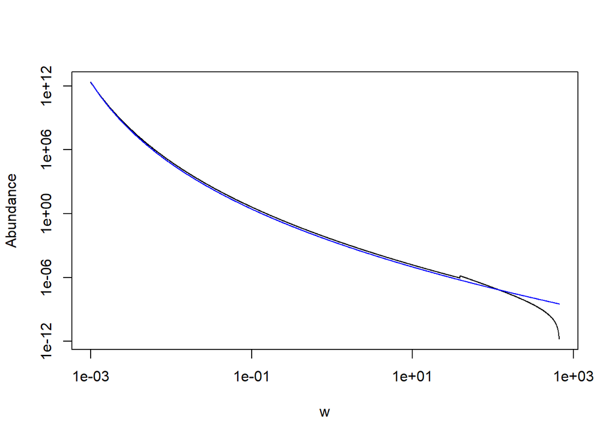

```r
sim <- project(params, t_max=500, effort = 0, initial_n = n_exact)
plot(w, sim@n[dim(sim@n)[1],1,], log="xy", type="l", ylab="Abundance")
lines(w, n_exact[1,], col="blue")
```

```r
rdi_old_erepro <- getRDI(params, matrix(sim@n[dim(sim@n)[1], , ], nrow = 1), params@cc_pp)[1,1]
params@species_params$erepro <- params@species_params$erepro * R/rdi_old_erepro
```

now let us check that we are now making the correct number of eggs

```r
rdi <- getRDI(params, matrix(sim@n[dim(sim@n)[1], , ], nrow = 1), params@cc_pp)[1,1]

rdi/R
```

```
## Single
##      1
```

now we shall allow the number of eggs to be dynamic

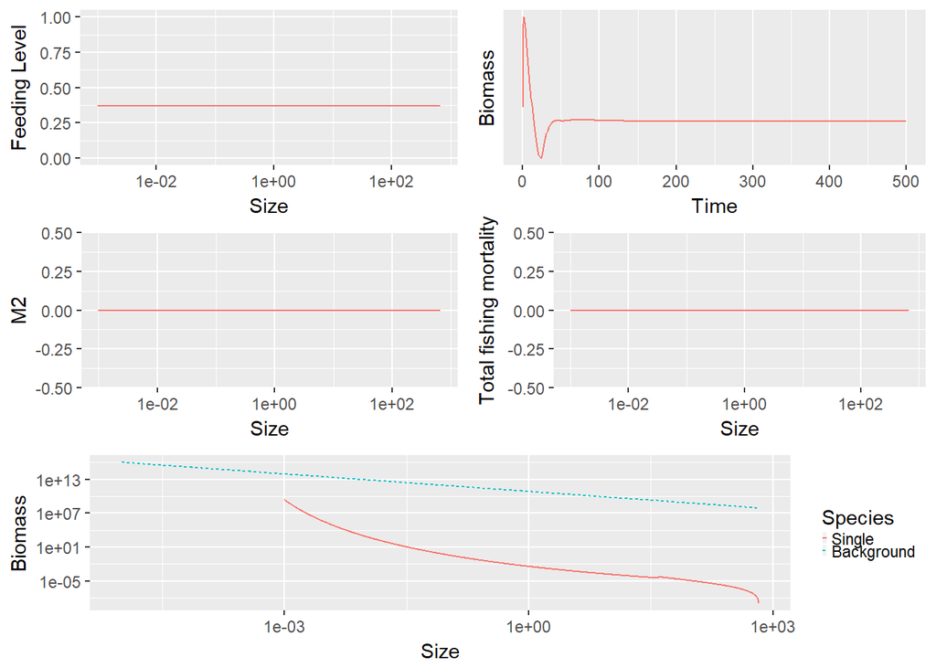

```r
params@srr <- function(rdi, species_params) {return(rdi)}
sim <- project(params, t_max=500, effort = 0, initial_n = n_exact)
plot(sim)
```

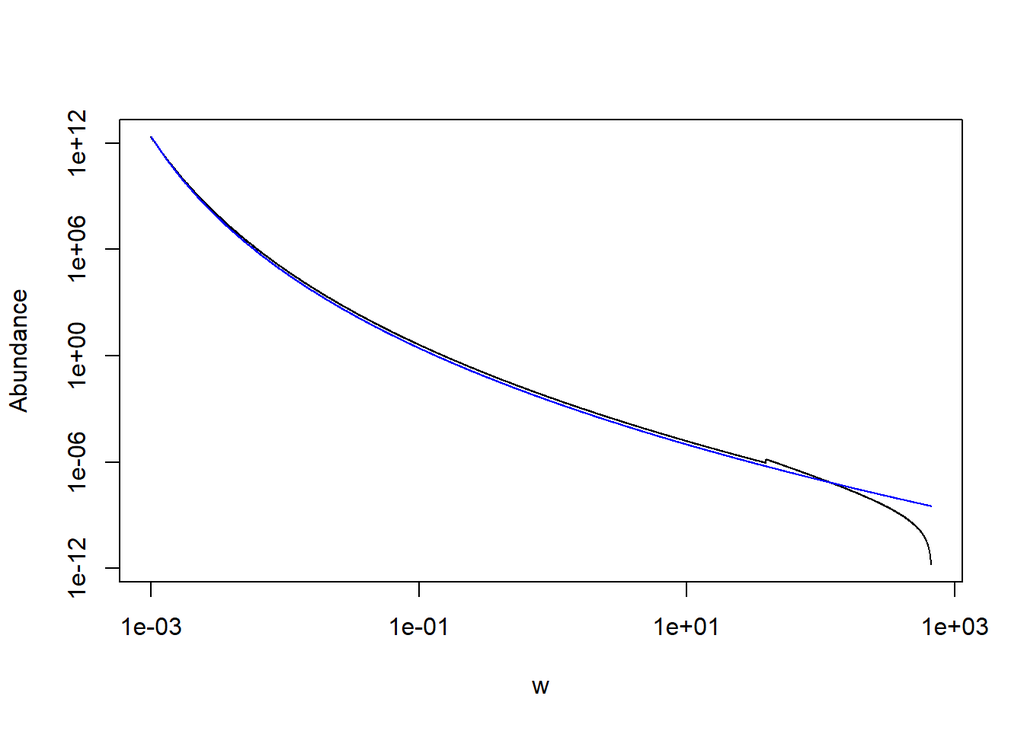

```r
plot(w, sim@n[dim(sim@n)[1],1,], log="xy", type="l", ylab="Abundance")
lines(w, n_exact[1,], col="blue")
```

For these type of solutions that curl up, a large no_w seems to be required to avoid numerical errors when determining RDI Things to do: figure out how to get gurnard to exist when R is not fixed turn on chi, predict effect put gurnard in dynamic background automate solution Investigate the growth curves of these Gurnard get analytic formulas for f0 and mu0 when chi>0 document this with a nice markdown doc, including pde solution details too

```r
g <- getEGrowth(params, matrix(sim@n[dim(sim@n)[1], , ], nrow = 1), params@cc_pp)[1,]
```

calculate growth curve using ODE solving routine

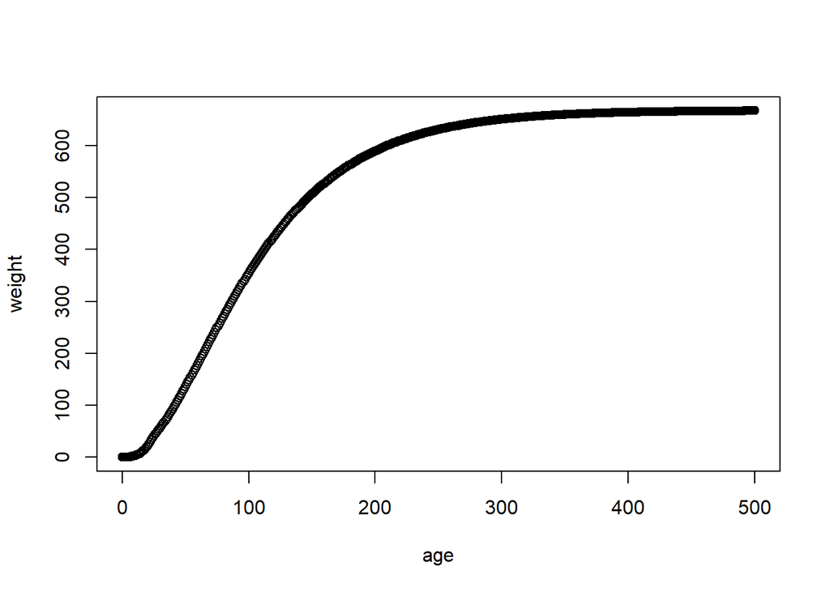

```r
g_fn <- approxfun(w, g)
myodefun <- function(t, state, parameters){
  return(list(g_fn(state)))
}
age <- (0:500)
library(deSolve)
weight <- ode(y = w[1], times = age, func = myodefun, parms = 1)[,2]
plot(age,weight)
```

calculate growth curve in another way via direct integration

```r
#lines(cumsum((w[2:no_w]-w[1:(no_w-1)])/g[1:(no_w-1)]),w[1:(no_w-1)],xlab="age",ylab="weight",col="red")
```